# Этап индивидуального проекта №1

Операционные системы

Закиров Н.Д., НКАбд-03-23

Российский университет дружбы народов, Москва, Россия

2 марта 2024

# Информация

## Докладчик

- Закиров Нурислам Дамирович
- Студент 1 курса
- Группа: НКАбд-03-23
- Российский университет дружбы народов

# Лабораторная работа

## Цель работы

Целью данной лабораторной работы является научиться размещать сайт на Github pages. Выполнить первый этап реализации индивидуального проекта.

# Задание

- Установить необходимое ПО
- Скачать шаблон темы сайта
- Разместить его на хостинге Git
- Установить параметр для URLs сайта
- Разместить заготовку сайта на Github pages.

# Выполнение этапа индивидуального проекта

## Установка необходимого ПО

Скачиваю последнюю версию исполняемого файла hugo для своей операционной системы (рис. 1).

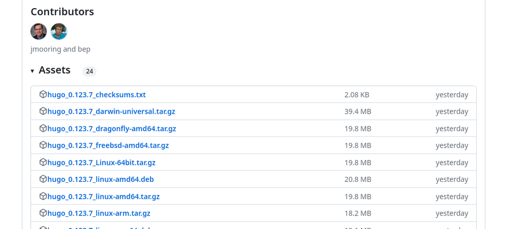

Выбор версии ПО

## Установка необходимого ПО

Распаковываю архив с исполняемым файлом (рис. 2).

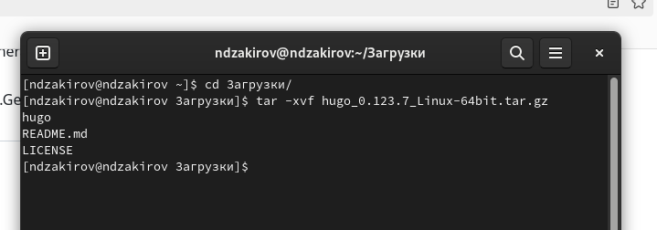

Распаковка архива

## Установка необходимого ПО

Создаю в домашнем каталоге пустую папку bin с помощью утилиты mkdir, переношу в эту папку исполняемый файл hugo (рис. 3).

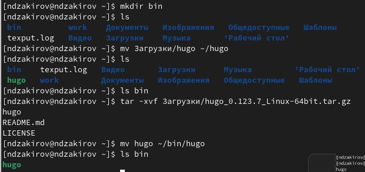

Перемещение файла

## Скачивание шаблона темы сайта

Открываю репозиторий с шаблоном темы сайта (рис. 4).

[figure not shown]

Репозиторий с шаблоном темы сайта

## Скачивание шаблона темы сайта

Создаю свой репозиторий blog на основе репозитория с шаблоном темы сайта (рис. 5).

[figure not shown]

Создание репозитория

## Скачивание шаблона темы сайта

Клонирую созданный репозиторий к себе в локальный репозиторий (рис. 6).

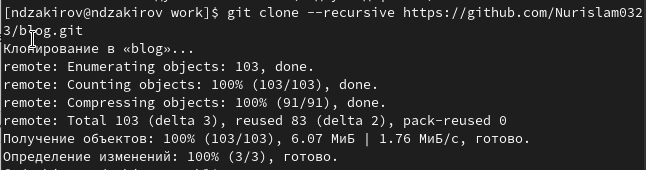

Клонирование репозитория

## Размещение его на хостинге Git

Запускаю исполняемый файл (рис. 7).

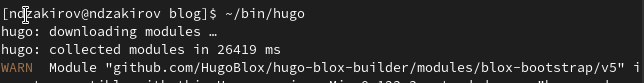

Запуск исполняемого файла

## Размещение его на хостинге Git

Удаляю папку public которая сейчас нам не понадобится, тем более мы создадим свою (рис. 8).

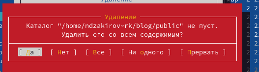

Удаление каталога

## Размещение его на хостинге Git

Снова запускаю исполняемый файл с командой server (рис. 9).

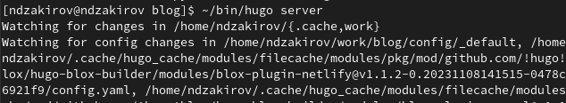

Запуск исполняемого файла

## Размещение его на хостинге Git

Получилась страничка сайта на локальном сервере (рис. 10).

[figure not shown]

Сайт на локальном сервере

## Установка параметр для URLs сайта

Теперь создаю новый пустой репозиторий чье имя будет адресом сайта (рис. 11).

[figure not shown]

Создание репозитория

## Установка параметр для URLs сайта

Клонирую созданный репозиторий, чтобы создать локальный репозиторий у себя на компьютере (рис. 12).

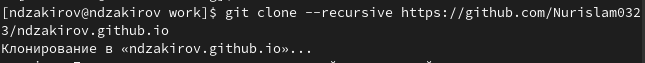

Клонирование репозитория

## Установка параметр для URLs сайта

Создаю главную ветку с именем main (рис. 13).

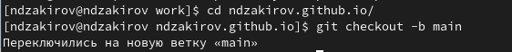

Создание главное ветки

## Установка параметр для URLs сайта

Создаю пустой файл README.md и отправляю изменения на глобальный репозиторий, чтобы его активировать (рис. 14).

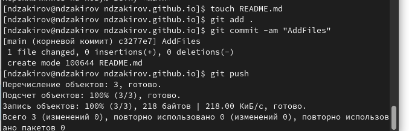

Создание файла

## Установка параметр для URLs сайта

Подключаю репозиторий к каталогу public (рис. 15).

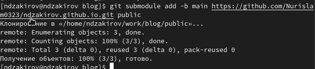

Подключаение репозитория к каталогу

## Установка параметр для URLs сайта

Снова выполняю команду исполняемого файла, чтобы заполнить создавшийся каталог public (рис. 16).

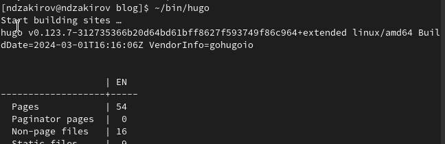

## Размещение заготовку сайта на Github pages.

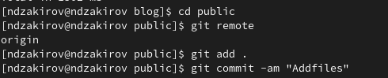

## Выводы

Я научился размещать сайт на Github pages и, следовательно, выполнил первый этап реализации индивидуального проекта.